# ds202_lab2

```r
count
```

```
##
##        Amsterdam Argentina Australia Austria Belgium Bolivia Brazil Canada
##   1            0         0         0       0       3       0      0      0
##   1.5          0         0         0       0       1       0      0      0
##   1.75         0         0         0       0       0       0      0      0
##   2            0         0         0       0       1       0      0      2
##   2.25         0         0         0       0       0       0      0      0
##   2.5          0         0         3       0       1       0      1      4
##   2.6          0         0         0       0       0       0      0      0
##   2.75         0         2         5       4       6       1      2     22
##   3            3         0         6       8      18       0      5     26
##   3.25         5         2        11       5       7       0      6     35
##   3.5          2         4        12       9      11       0      6     32
##   3.75         2         1        12       4       6       1      3     27
##   4            0         0         4       0       5       0      1     13
##
##        Chile Colombia Costa Rica Czech Republic Denmark Dominican Republic
##   1        0        0          0              0       0                  0
##   1.5      0        0          0              0       0                  0
##   1.75     0        0          0              0       0                  0
##   2        0        1          0              0       0                  0
##   2.25     0        0          0              0       0                  0
##   2.5      0        1          1              0       2                  1
##   2.6      0        0          0              0       0                  1
##   2.75     0        4          1              2       1                  0
##   3        0        6          2              0       4                  4
##   3.25     0        4          2              0      10                  2
##   3.5      0        5          3              1       7                  2
##   3.75     2        4          0              0       5                  1
##   4        0        0          0              0       2                  0
##
##        Ecuador El Salvador Fiji Finland France Germany Ghana Grenada Guatemala
##   1          0           0    0       0      0       0     0       0         0
##   1.5        2           0    0       0      2       1     0       0         0
##   1.75       0           0    0       0      0       0     0       0         0
##   2          3           0    0       0      7       0     0       0         0
##   2.25       0           0    0       0      0       0     0       0         0
##   2.5        6           0    0       0      6       3     0       1         0
##   2.6        0           0    0       0      0       0     0       0         0
##   2.75       8           1    1       0     20       4     1       1         1
```

[output cut: 80 more lines]

```
##
##        Thailand U.A.E. U.K. U.S.A. Vanuatu Venezuela Vietnam Wales
##   1           0      0    0      0       0         0       0     0
##   1.5         0      0    0      2       0         0       0     0
##   1.75        0      0    3      0       0         0       0     0
##   2           0      0    0     15       0         0       0     0
##   2.25        0      0    4      8       0         0       0     0
##   2.5         0      0   11     78       1         5       0     0
##   2.6         0      0    0      0       0         0       0     0
##   2.75        1      0   29    136       2         4       1     1
##   3           1      1   25    207       1         8       3     0
##   3.25        0      1   17    171       0         4       2     0
##   3.5         2      2   22    207       0         6       8     0
##   3.75        1      1   11    106       0         4       1     0
##   4           0      0    4     36       0         0       0     0
```

Some countries, like the USA, dominate the number of reviews. This could be for many reasons but more than a third of the reviews are from one country.

```r
model = lm(Rating~Cocoa_Percent, data=choco)
summary(model)
```

```
##
## Call:
## lm(formula = Rating ~ Cocoa_Percent, data = choco)
##
## Residuals:
##      Min       1Q   Median       3Q      Max
## -2.20359 -0.26278  0.04641  0.29641  1.00951
##
## Coefficients:
##                Estimate Std. Error t value Pr(>|t|)
## (Intercept)    4.032306   0.115896  34.793  < 2e-16 ***
## Cocoa_Percent -0.011839   0.001612  -7.342 2.89e-13 ***
## ---
## Signif. codes:  0 '***' 0.001 '**' 0.01 '*' 0.05 '.' 0.1 ' ' 1
##
## Residual standard error: 0.4469 on 2310 degrees of freedom
## Multiple R-squared:  0.02281,    Adjusted R-squared:  0.02238
## F-statistic: 53.91 on 1 and 2310 DF,  p-value: 2.89e-13
```

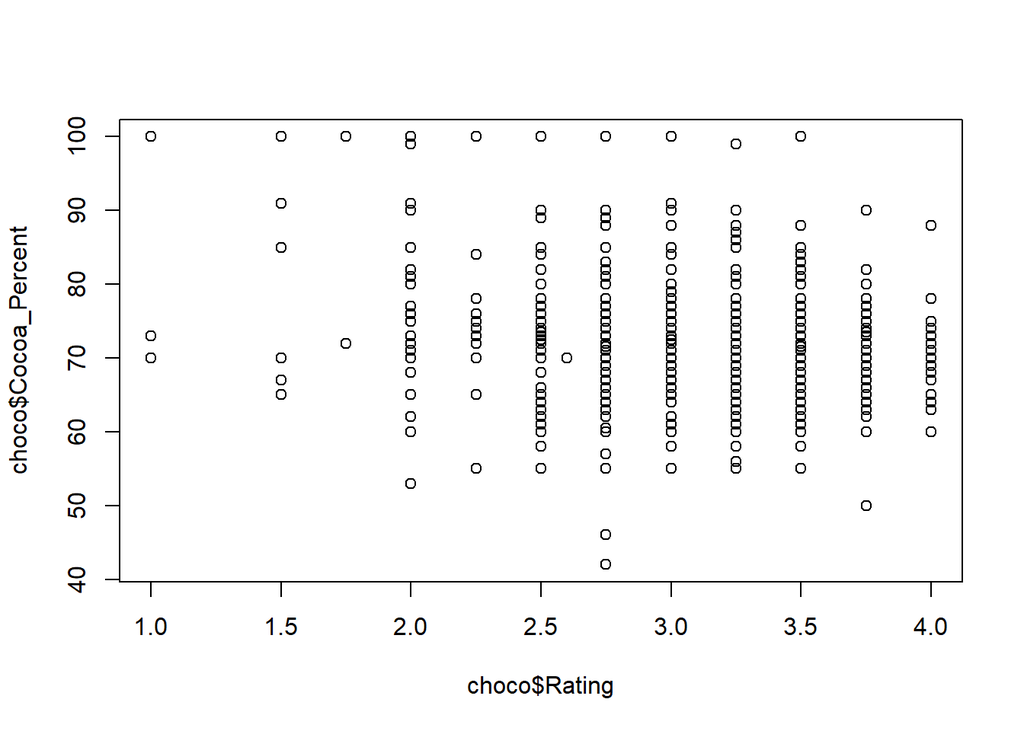

```r
plot(choco$Rating, choco$Cocoa_Percent)
```

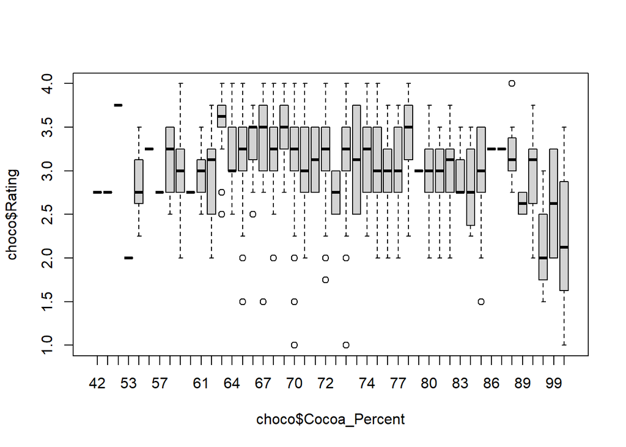

```r
boxplot(choco$Rating~choco$Cocoa_Percent)
```

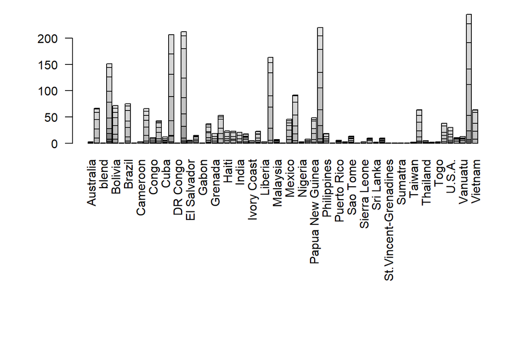

```r
count2 <- table(choco$Rating, choco$Bean_Origin)
par(mar=c(15,5,1,1))
barplot(count2, las=2)
```

```r
count2
```

```
##
##        Australia Belize blend Blend Bolivia Bolvia Brazil Burma Cameroon
##   1            0      0     0     3       0      0      0     0        0
##   1.5          0      0     0     5       0      0      0     0        0
##   1.75         0      0     0     0       0      0      1     0        0
##   2            0      0     0    11       1      0      0     0        0
##   2.25         0      0     0     0       0      0      0     0        0
##   2.5          0      1     0     9       7      0      3     0        0
##   2.6          0      0     0     0       0      0      0     0        0
##   2.75         1      9     0    20       9      0      8     0        0
##   3            0     17     1    30      17      0     18     1        2
##   3.25         1     18     0    21      15      1     12     0        1
##   3.5          0     14     0    27      10      0     20     0        0
##   3.75         1      6     0    18       8      0      9     0        0
##   4            0      2     0     7       5      0      4     0        0
##
##        Colombia Congo Costa Rica Cuba Dominican Republic DR Congo Ecuador
##   1           0     0          0    0                  0        0       1
##   1.5         0     0          0    0                  0        0       3
##   1.75        0     0          0    0                  0        0       0
##   2           1     0          1    0                  1        0       6
##   2.25        0     0          0    0                  2        0       0
##   2.5         3     0          3    1                 11        0      22
##   2.6         0     0          0    0                  1        0       0
##   2.75       11     1          5    1                 28        0      24
##   3          16     2         12    2                 46        1      31
##   3.25       13     3          9    2                 42        0      37
##   3.5         9     3          9    3                 39        0      56
##   3.75        8     2          2    3                 36        0      24
##   4           5     0          2    0                  0        0       8
##
##        El Salvador Fiji Gabon Ghana Grenada Guatemala Haiti Honduras India
##   1              0    0     0     0       0         0     0        0     0
##   1.5            0    0     0     1       0         0     0        0     0
##   1.75           0    0     0     0       0         0     0        0     0
##   2              0    0     0     1       0         0     0        0     0
##   2.25           0    0     0     0       1         0     0        0     0
##   2.5            0    2     0     4       3         1     1        1     2
##   2.6            0    0     0     0       0         0     0        0     0
##   2.75           2    3     0     5       5         8     4        5     1
```

[output cut: 80 more lines]

```
##
##        Uganda Vanuatu Venezuela Vietnam
##   1         0       0         0       0
##   1.5       0       0         0       0
##   1.75      0       0         1       0
##   2         0       0         3       0
##   2.25      0       0         3       0
##   2.5       4       1        17       0
##   2.6       0       0         0       0
##   2.75      4       4        29       8
##   3         1       3        59      15
##   3.25      0       1        29      15
##   3.5       1       1        50      21
##   3.75      1       3        36       4
##   4         0       0        18       1
```

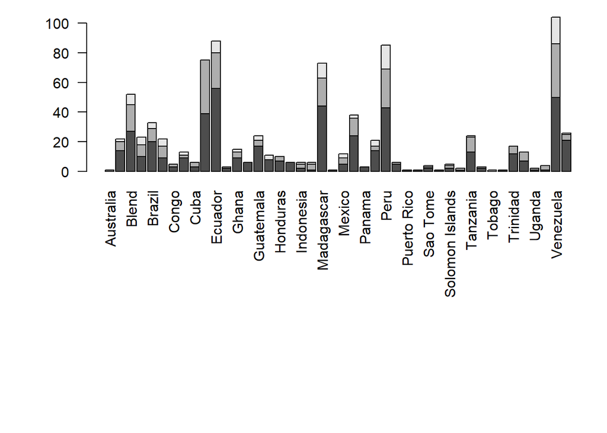

```r
highrate <- subset(choco, Rating>="3.5")
count3 <- table(highrate$Rating, highrate$Bean_Origin)
par(mar=c(15,5,1,1))
barplot(count3, las=2)
```

```r
count3
```

```
##
##        Australia Belize Blend Bolivia Brazil Colombia Congo Costa Rica Cuba
##   3.5          0     14    27      10     20        9     3          9    3
##   3.75         1      6    18       8      9        8     2          2    3
##   4            0      2     7       5      4        5     0          2    0
##
##        Dominican Republic Ecuador Fiji Ghana Grenada Guatemala Haiti Honduras
##   3.5                  39      56    2     9       6        17     8        7
##   3.75                 36      24    1     4       0         4     0        3
##   4                     0       8    0     2       0         3     3        0
##
##        India Indonesia Jamaica Madagascar Malaysia Mexico Nicaragua Panama
##   3.5      6         2       1         44        1      5        24      3
##   3.75     0         3       4         19        0      4        12      0
##   4        0         1       1         10        0      3         2      0
##
##        Papua New Guinea Peru Philippines Puerto Rico Samoa Sao Tome
##   3.5                14   43           5           1     1        2
##   3.75                3   26           1           0     0        1
##   4                   4   16           0           0     0        1
##
##        Sao Tome & Principe Solomon Islands St. Lucia Tanzania Thailand Tobago
##   3.5                    1               2         1       13        2      0
##   3.75                   0               2         0       10        1      0
##   4                      0               1         1        1        0      1
##
##        Togo Trinidad U.S.A. Uganda Vanuatu Venezuela Vietnam
##   3.5     1       12      7      1       1        50      21
##   3.75    0        5      6      1       3        36       4
##   4       0        0      0      0       0        18       1
```

After thining the data it becomes clear that some countries are able to produce better beans than others, after filtering by all down to only reviews of 3.5 or higher many countries where dropped and some where able to retain many of their reviews. Countries like ecuador and Venzuela are good examples of countries that produce excellent cocoa beans. 5)

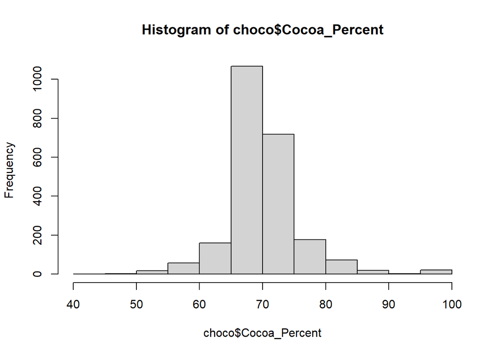

```r
hist(choco$Cocoa_Percent)
```

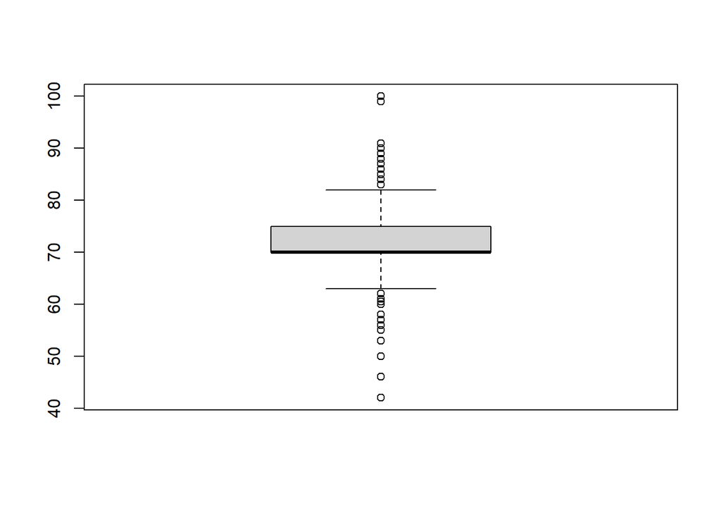

```r
boxplot(choco$Cocoa_Percent)
```

This chart shows the distribution of cocoa percents in various chocolates, the vast majority contain 65-75% cocoa, with outliers above 82~% range and below 62~% range.

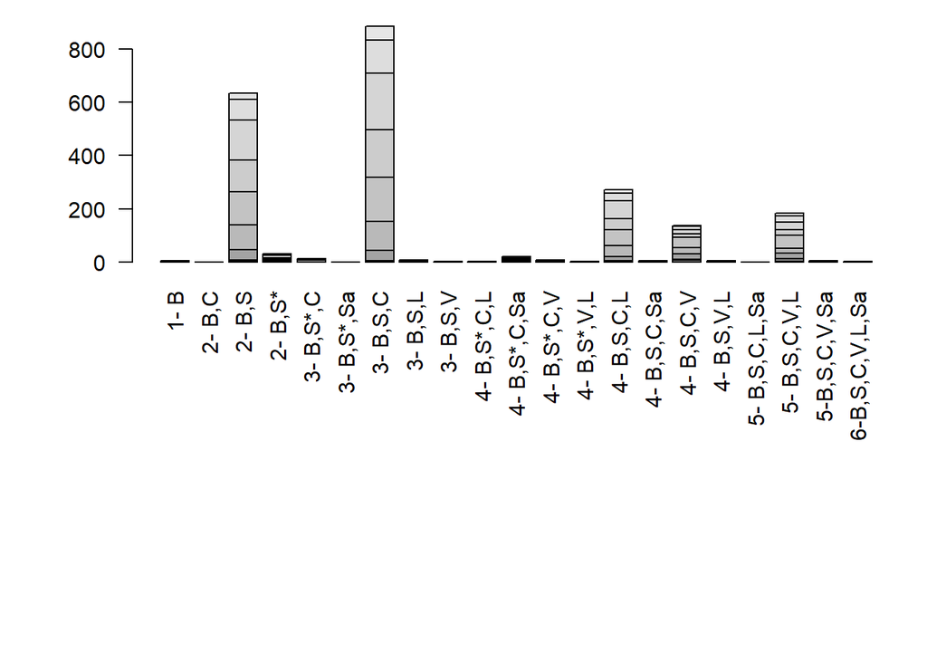

```r
count4 <- table(choco$Rating, choco$Ingredients)
par(mar=c(15,5,1,1))
barplot(count4, las=2)
```

```r
count4
```

```
##
##        1- B 2- B,C 2- B,S 2- B,S* 3- B,S*,C 3- B,S*,Sa 3- B,S,C 3- B,S,L
##   1       0      0      0       0         0          0        0        0
##   1.5     0      0      0       0         0          0        1        1
##   1.75    0      0      0       0         0          0        1        0
##   2       0      0      3       1         0          0        0        0
##   2.25    0      0      5       2         0          0        3        1
##   2.5     1      0     39       6         0          1       40        0
##   2.6     0      0      1       0         0          0        0        0
##   2.75    1      0     91       4         7          0      108        2
##   3       2      1    125       3         2          0      166        3
##   3.25    0      0    120       9         2          0      179        1
##   3.5     1      0    149       6         1          0      212        0
##   3.75    0      0     78       0         0          0      122        0
##   4       0      0     22       0         0          0       53        0
##
##        3- B,S,V 4- B,S*,C,L 4- B,S*,C,Sa 4- B,S*,C,V 4- B,S*,V,L 4- B,S,C,L
##   1           0           0            0           0           0          0
##   1.5         0           0            1           0           0          1
##   1.75        0           0            0           0           0          0
##   2           0           0            1           0           0          5
##   2.25        0           0            0           0           0          0
##   2.5         1           0            1           0           0         15
##   2.6         0           0            0           0           0          0
##   2.75        0           1            1           1           0         41
##   3           0           1            5           5           2         60
##   3.25        0           0            3           1           1         42
##   3.5         2           0            5           0           0         66
##   3.75        0           0            3           0           0         29
##   4           0           0            0           0           0         13
##
##        4- B,S,C,Sa 4- B,S,C,V 4- B,S,V,L 5- B,S,C,L,Sa 5- B,S,C,V,L
##   1              0          0          0             0            1
##   1.5            0          0          0             0            1
##   1.75           0          0          0             0            0
##   2              0          7          0             0           12
##   2.25           0          3          0             0            0
##   2.5            0         21          1             0           21
##   2.6            0          0          0             0            0
##   2.75           0         24          2             0           17
##   3              2         39          1             1           50
##   3.25           3         12          0             0           21
##   3.5            0         17          1             0           28
##   3.75           0         11          0             0           22
##   4              0          2          0             0           11
##
##        5-B,S,C,V,Sa 6-B,S,C,V,L,Sa
##   1               0              0
##   1.5             0              0
##   1.75            0              0
##   2               0              0
##   2.25            0              0
##   2.5             2              0
##   2.6             0              0
##   2.75            1              3
##   3               3              0
##   3.25            0              0
##   3.5             0              1
##   3.75            0              0
##   4               0              0
```

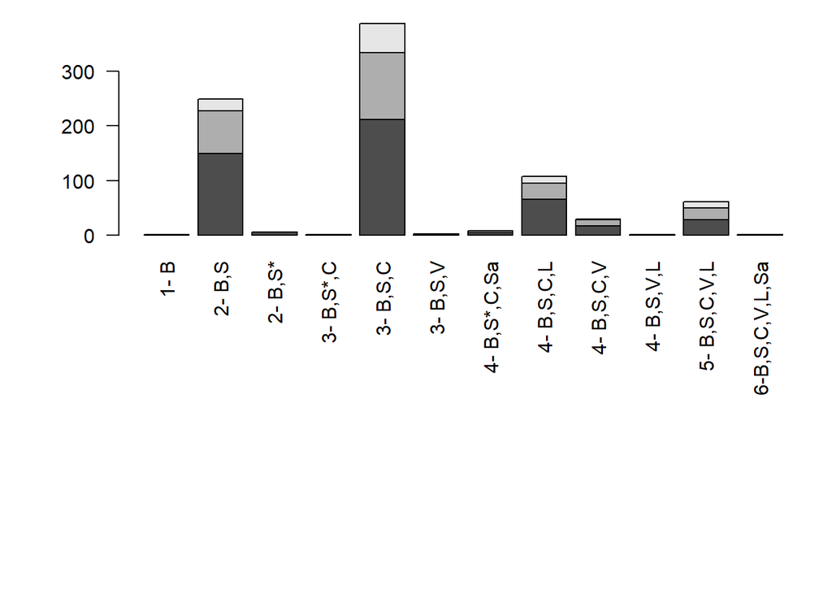

```r
count5 <- table(highrate$Rating, highrate$Ingredients)
par(mar=c(15,5,1,1))
barplot(count5, las=2)
```

```r
count5
```

```
##
##        1- B 2- B,S 2- B,S* 3- B,S*,C 3- B,S,C 3- B,S,V 4- B,S*,C,Sa 4- B,S,C,L
##   3.5     1    149       6         1      212        2            5         66
##   3.75    0     78       0         0      122        0            3         29
##   4       0     22       0         0       53        0            0         13
##
##        4- B,S,C,V 4- B,S,V,L 5- B,S,C,V,L 6-B,S,C,V,L,Sa
##   3.5          17          1           28              1
##   3.75         11          0           22              0
##   4             2          0           11              0
```

This data was to try to see is ingredients had a role in how the chocolate would be scored, despite being filtered by score, the distribution of scores stayed very similar to the unfiltered layout, this leads me to conclude that ingredients play little role in the final rating of the chocolate, as long as they are standard ingredients.